# Machine Learning with `caret` in R (DataCamp)

## Preprocessing your data

**Median imputation**

Dealing with missing values:

- Real-world data has missing values
- Most models require numbers, can’t handle missing data
- Common approach: remove rows with missing data
  - Can lead to biases in data
  - Generate over-confident models
- The authors of the caret package favor a median imputation
  - Replace missing values with medians
  - Works well if data is missing at random (MAR)

```r
# Getting the data
cancer.url <- "http://archive.ics.uci.edu/ml/machine-learning-databases/breast-cancer-wisconsin/breast-cancer-wisconsin.data"
cancer.raw <- read.csv(cancer.url, header = TRUE)
BreastCancer <- cancer.raw[,-1]

# Correcting the variable names
columns <- c("Cl.thickness", "Cell.size", "Cell.shape", "Marg.adhesion", "Epith.c.size", "Bare.nuclei", "Bl.cromatin", "Normal.nucleoli", "Mitoses", "Class")
names(BreastCancer) <- columns
glimpse(BreastCancer)
```

```
## Rows: 698
## Columns: 10
## $ Cl.thickness    <int> 5, 3, 6, 4, 8, 1, 2, 2, 4, 1, 2, 5, 1, 8, 7, 4, 4, ...
## $ Cell.size       <int> 4, 1, 8, 1, 10, 1, 1, 1, 2, 1, 1, 3, 1, 7, 4, 1, 1,...
## $ Cell.shape      <int> 4, 1, 8, 1, 10, 1, 2, 1, 1, 1, 1, 3, 1, 5, 6, 1, 1,...
## $ Marg.adhesion   <int> 5, 1, 1, 3, 8, 1, 1, 1, 1, 1, 1, 3, 1, 10, 4, 1, 1,...
## $ Epith.c.size    <int> 7, 2, 3, 2, 7, 2, 2, 2, 2, 1, 2, 2, 2, 7, 6, 2, 2, ...
## $ Bare.nuclei     <chr> "10", "2", "4", "1", "10", "10", "1", "1", "1", "1"...
## $ Bl.cromatin     <int> 3, 3, 3, 3, 9, 3, 3, 1, 2, 3, 2, 4, 3, 5, 4, 2, 3, ...
## $ Normal.nucleoli <int> 2, 1, 7, 1, 7, 1, 1, 1, 1, 1, 1, 4, 1, 5, 3, 1, 1, ...
## $ Mitoses         <int> 1, 1, 1, 1, 1, 1, 1, 5, 1, 1, 1, 1, 1, 4, 1, 1, 1, ...
## $ Class           <int> 2, 2, 2, 2, 4, 2, 2, 2, 2, 2, 2, 4, 2, 4, 4, 2, 2, ...
```

```r
# Splitting the data in x and y
# Creating two data-sets
breast_cancer_x <- BreastCancer[,c(1:9)]
breast_cancer_y <- BreastCancer[,10]

names_x <- names(breast_cancer_x)
# Creating Missings at Random (MAR)

set.seed(42)
for(val in names_x){
    breast_cancer_x[sample(1:nrow(breast_cancer_x), 100), val] <- NA
}

#Recode breast_cancer_y with ifelse
breast_cancer_y <- ifelse(breast_cancer_y==2, "benign", "malignant")

# Apply median imputation: median_model
median_model <- train(
  x = breast_cancer_x,
  y = breast_cancer_y,
  method = "glm",
  trControl = myControl,
  preProcess = "medianImpute"
)
# Print median_model to console
median_model
```

```
## Generalized Linear Model
##
## 698 samples
##   9 predictor
##   2 classes: 'benign', 'malignant'
##
## Pre-processing: median imputation (8), ignore (1)
## Resampling: Cross-Validated (10 fold)
## Summary of sample sizes: 628, 628, 628, 629, 628, 628, ...
## Resampling results:
##
##   ROC        Sens       Spec
##   0.9882499  0.9764077  0.9512875
```

**My advise against mean/median imputation!**

To this day, a lot of teachers and manuals advise mean and median imputations for replacing missing values in their data sets. I find this highly problematic because these methods skew your results.

The problem with mean imputations:

- Let’s have a look at the formula for the standard deviation: $\sqrt{\frac{1}{N-1}\sum \limits_{i=1}^N (x_i-\bar{x})}$, with $x_i$ being the observed value and $\bar{x}$ the mean of all observations.
- If we would impute a missing value with the mean, $x_i$ would equal to $\bar{x}$.
- This would lead the substrate of $x_i-\bar{x}$ to be 0! Ultimately decreasing the variance in your data
- For those interested in Confidence Intervals and p-Values: Since the formula of the standard deviation is used to calculate these metrics, we would underestimate the size both of these metrics. This would lead you to be overconfident with your results!

Similar problems could occur with median imputations. Often the mean and median of a distribution are close to each other. They are so the more symmetrically distributed your data is!

Even when in regards to predictive modeling, incorrect results can be produced if data is missing not at random!

**KNN imputation**

As an alternative to median imputation:

- k-nearest neighbors (KNN) imputation
- Imputes based on “similar” non-missing rows
- The `train` function implements KNN imputations

When missing values are not at random, KNN imputation is better and yields more accurate (but slower) results than median imputation.

As you can see in the results below, the KNN-imputation performs slightly better than the median one!

```r
# Apply KNN imputation: knn_model
set.seed(42)
knn_model <- train(
  x = breast_cancer_x,
  y = breast_cancer_y,
  method = "glm",
  trControl = myControl,
  preProcess = "knnImpute"
)
# Print knn_model to console
knn_model
```

```
## Generalized Linear Model
##
## 698 samples
##   9 predictor
##   2 classes: 'benign', 'malignant'
##
## Pre-processing: nearest neighbor imputation (8), ignore (1), centered
##  (8), scaled (8)
## Resampling: Cross-Validated (10 fold)
## Summary of sample sizes: 629, 628, 629, 628, 628, 629, ...
## Resampling results:
##
##   ROC        Sens       Spec
##   0.9891962  0.9739677  0.952586
```

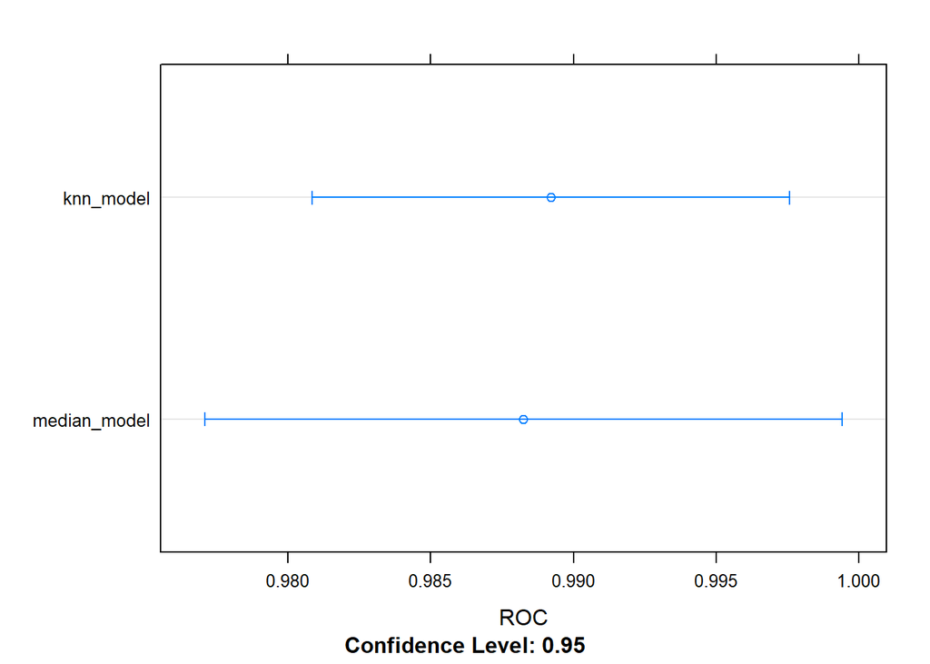

```r
# Let's compare both
resamples <- resamples(x=list(median_model = median_model, knn_model = knn_model))
dotplot(resamples, metric = "ROC")
```

**Multiple preprocessing methods**

The wide world of preProcess:

- You can do a lot more than median or knn imputation!
- Can chain together multiplte preprocessing steps
- Common “recipe” for linear models (order matters!)
  - Median imputation => center => scale => fit glm
  - Principle Component Analysis (PCA) always happens after centering and scaling the data
- See `?preProcess` for more details

Preprocessing cheat sheet:

- Start with median imputation
- Try KNN imputation if data missing not at random
- For linear models (lm, glm, glmnet, etc.)…
  - Center and scale
  - Try PCA and spatial sign (`spatialSign`, for data with many outliers or high dimensional data)
- Tree-based models don’t need much preprocessing. Often you get away with just median imputation.

```r
model <- train(
  x = breast_cancer_x,
  y = breast_cancer_y,
  method = "glm",
  trControl = myControl,
  preProcess = c("medianImpute","center","scale")
)
# Print model
model
```

```
## Generalized Linear Model
##
## 698 samples
##   9 predictor
##   2 classes: 'benign', 'malignant'
##
## Pre-processing: median imputation (8), centered (8), scaled (8), ignore (1)
## Resampling: Cross-Validated (10 fold)
## Summary of sample sizes: 628, 627, 628, 629, 628, 629, ...
## Resampling results:
##
##   ROC        Sens      Spec
##   0.9897184  0.977474  0.9209285
```

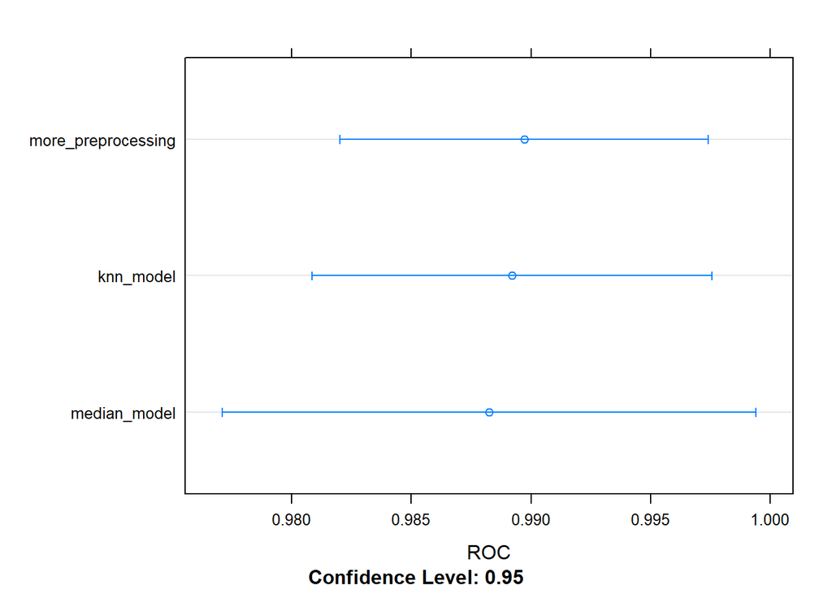

```r
resamples <- resamples(x=list(median_model = median_model, knn_model = knn_model, more_preprocessing=model))
dotplot(resamples, metric = "ROC")
```

**Handling low-information predicators**

No (or low) variance variables:

- Some variables don’t contain much information
  - Constant (i.e. no variance)
  - Nearly constant (i.e. low variance)
- Easy for one fold of CV to end up with constant column
  - Can cause problems for your models
  - Tend to have no impact on your model, as they have contibute variance/information to it.
- Common practice is: Remove extremely low variance variables
  - Runs faster
  - Does not have much impact on your model accuracy

The `caret` way to deal with this:

- `zv` removes constant columns
- `nzv` removes nearly constant columns
- These variables can be removed a-priori or within the train process, as method in `preProcess`

```r
data(BloodBrain)

bloodbrain_x <- bbbDescr
bloodbrain_y <- logBBB

# Identify near zero variance predictors: remove_cols
remove_cols <- nearZeroVar(bloodbrain_x, names = TRUE, freqCut = 2, uniqueCut = 20)

# Get all column names from bloodbrain_x: all_cols
all_cols <- names(bloodbrain_x)

# Remove from data: bloodbrain_x_small
bloodbrain_x_small <- bloodbrain_x[ , setdiff(all_cols, remove_cols)]

# Fit model on reduced data: model
model <- train(
  x = bloodbrain_x_small,
  y = bloodbrain_y,
  method = "glm"
)
```

[output not shown]

[output cut: 19 more lines]

[output not shown]

```r
# Print model to console
model
```

```
## Generalized Linear Model
##
## 208 samples
## 112 predictors
##
## No pre-processing
## Resampling: Bootstrapped (25 reps)
## Summary of sample sizes: 208, 208, 208, 208, 208, 208, ...
## Resampling results:
##
##   RMSE      Rsquared   MAE
##   1.825975  0.1039272  1.100235
```

**Principle components analysis (PCA)**

- We know PCA as a form of analysis that allows to find structure in our data and cluster certain informations
- As a preprocessing function, we can use PCA to combine low-variance and correlated variables
- Into a single set of high-variance, perpendicular predictors
- It’s better to find a systematic way to use that information rather tahan throwing it away
- Prevents collinearity (i.e. correlation among predictors)

PCA searches for high-variance, linear combination of the input-data that are perpendicular to each other:

- The first component has highest variance
- Second component has second variance
- And so on …

Look at the figure below. We have two correlated variables, x and y. When plotted together we can see the relationship. PCA transforms this data with respect to that correlation and finds a new variable - the long diagonal arrow pointing up and to the right (first component). That reflects the shared correlation between x and y. The second component has to be orthogonal to the first one - shown in the second arrow, going up and to the left. The first PCA component reflects the similarity between x and y, while the second one emphasized their difference.

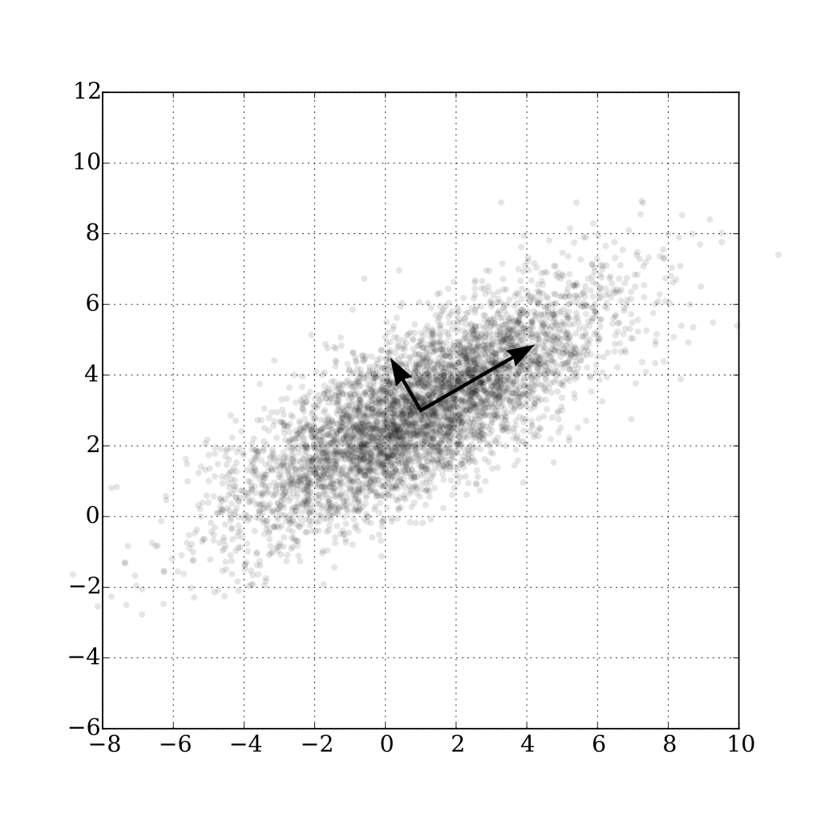

```r
data(BloodBrain)

bloodbrain_x <- bbbDescr
bloodbrain_y <- logBBB

# Fit glm model using PCA: model
model <- train(
  x = bloodbrain_x,
  y = bloodbrain_y,
  method = "glm",
  preProcess = c("zv","pca")
)

# Print model to console
model
```

```
## Generalized Linear Model
##
## 208 samples
## 134 predictors
##
## Pre-processing: principal component signal extraction (134), centered
##  (134), scaled (134)
## Resampling: Bootstrapped (25 reps)
## Summary of sample sizes: 208, 208, 208, 208, 208, 208, ...
## Resampling results:
##
##   RMSE      Rsquared   MAE
##   0.608312  0.4276627  0.4545004
```

## Selecting models: a case study in churn prediction

**Reusing a trainControl**

A real-world example: + The data: customer churn at a telecom company + Fit different models and choose the best + Models must use the same training/test splits + We can do that by creating a shared `trainControl` object. This specifies which rows we use for model-building.

Note: When doing CV, caret tries to keep the ratio of positive to negative results in the fold-data as in the data overall (here approx. 15/85).

```r
# Get the data from Github
library(BDgraph)
data("churn")

#Churn y and x
churn_y <- churn$Churn
churn_x <- churn[,-20]

# Create custom indices: myFolds (for a 5-fold CV)
myFolds <- createFolds(churn_y, k = 5)

# Create reusable trainControl object: myControl
myControl <- trainControl(
  summaryFunction = twoClassSummary,
  classProbs = TRUE, # IMPORTANT!
  verboseIter = TRUE,
  savePredictions = TRUE,
  index = myFolds
)
```

**Reintroducing glmnet**

glmnet review:

- Linear model with built-in variable selection
- Great baselne model
- Advantages:
  - Fits quickly
  - Ignores noisy variables
  - Provides interpretable coefficients (just like in lm or glm)

```r
# Fit glmnet model: model_glmnet
train <- data.frame(churn_x, churn_y)

model_glmnet <- train(churn_y ~ ., data = train,
  metric = "ROC",
  method = "glmnet",
  trControl = myControl
)
```

**Reintroducing random forest**

Random forest review;

- Slower to fit than glmnet
- Less interpretable
- Often (but not always) more accurate than glmnet
- Easier to tune (only one parameter `mtry`)
- Require little preprocessing. Random forest models are more robust to zero/near-zero variance variables, outliers, collinearity, and missings not at random etc.
- Capture threshold effects and variable interactions

```r
# Fit random forest: model_rf
model_rf <- train(churn_y ~ ., data = train,
  metric = "ROC",
  method = "ranger",
  trControl = myControl
)
```

**Comparing models**

After fitting two or more models, we can compare them to see wich one fits new data the best:

- Make sure they were fit on the same data!
- Selection criteria:
  - Highest average AUC
  - Lowest standard deviation in AUC
- The `resamples()` function, as used before, helps us doing this

```r
# Create model_list
model_list <- list(glmnet = model_glmnet, rf = model_rf)

# Pass model_list to resamples(): resamples
resamples <- resamples(model_list)

# Summarize the results
summary(resamples)
```

```
##
## Call:
## summary.resamples(object = resamples)
##
## Models: glmnet, rf
## Number of resamples: 5
##
## ROC
##             Min.   1st Qu.    Median      Mean   3rd Qu.      Max. NA's
## glmnet 0.7888567 0.7933392 0.8116290 0.8059274 0.8178487 0.8179631    0
## rf     0.8902009 0.9032366 0.9062775 0.9046853 0.9089045 0.9148072    0
##
## Sens
##             Min.   1st Qu.    Median      Mean   3rd Qu.      Max. NA's
## glmnet 0.9754386 0.9820175 0.9837719 0.9851754 0.9903509 0.9942982    0
## rf     0.9767544 0.9771930 0.9868421 0.9841228 0.9881579 0.9916667    0
##
## Spec
##              Min.   1st Qu.     Median      Mean   3rd Qu.      Max. NA's
## glmnet 0.05440415 0.0620155 0.09326425 0.1003990 0.1243523 0.1679587    0
## rf     0.62015504 0.6373057 0.65374677 0.6599617 0.6683938 0.7202073    0
```

**But wait, there is more**

- We can plot the results of the model comparisons
- We can combine our models to a meta-model [caretStack](https://rdrr.io/cran/caretEnsemble/man/caretStack.html)

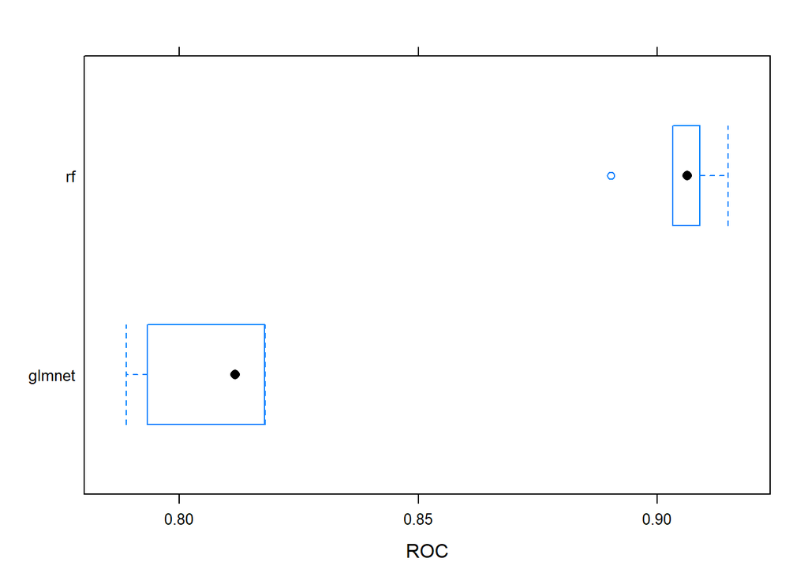

```r
bwplot(resamples, metric="ROC") ## RF performs better
```

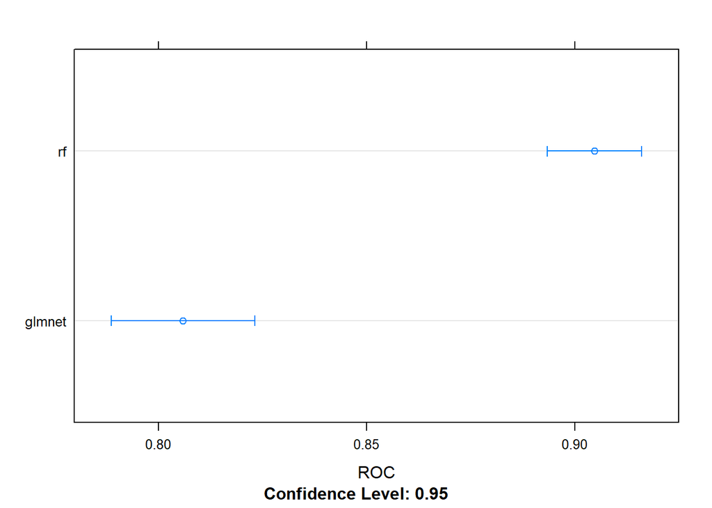

```r
dotplot(resamples, metric = "ROC") ## RF performs better
```

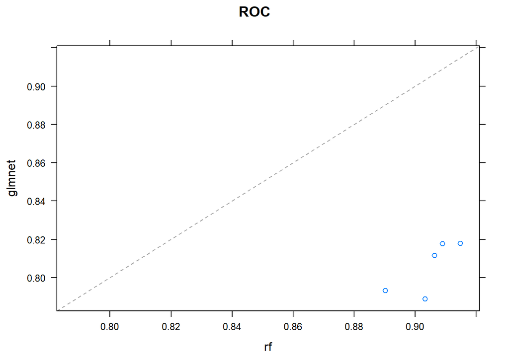

```r
xyplot(resamples, metric="ROC") ## RF was better in every fold
```

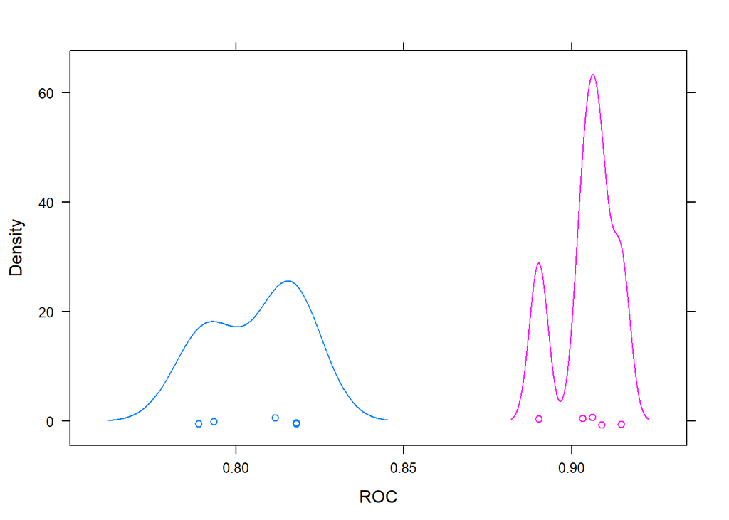

```r
densityplot(resamples, metric="ROC") ## Outlier folds exist in RF models (see spikes and near zero values)
```

```r
## Ensembling models
library(caretEnsemble)
#Caret list
models <- caretList(churn_y ~ ., data=train, trControl = myControl, methodList=c("glmnet", "ranger"))
# Create ensemble model: stack
stack <- caretStack(models, method="glm")

# Look at summary
summary(stack)
```

```
##
## Call:
## NULL
##
## Deviance Residuals:
##     Min       1Q   Median       3Q      Max
## -2.5448  -0.2745  -0.2145  -0.2017   2.8108
##
## Coefficients:
##             Estimate Std. Error z value Pr(>|z|)
## (Intercept)   4.6678     0.2004  23.289   <2e-16 ***
## glmnet       -0.6183     0.2689  -2.299   0.0215 *
## ranger       -7.9931     0.1693 -47.210   <2e-16 ***
## ---
## Signif. codes:  0 '***' 0.001 '**' 0.01 '*' 0.05 '.' 0.1 ' ' 1
##
## (Dispersion parameter for binomial family taken to be 1)
##
##     Null deviance: 11033.2  on 13331  degrees of freedom
## Residual deviance:  5235.6  on 13329  degrees of freedom
## AIC: 5241.6
##
## Number of Fisher Scoring iterations: 6
```

```r
# We can make predictions from stacking models!
predictions <- predict(stack, level = 0.95)  ##newdata is needed! now the precitions will be on training data
predictions[200:220]
```

```
##  [1] False False False False False False False False False False False False
## [13] False False False True  False False False True  False
## Levels: False True
```